# Второй этап Индивидуального проекта

Операционные системы - Бекауов А.Т

Российский университет дружбы народов, Москва, Россия

# Введение

## Цель работы

Целью данной работы добавление данных о себе на сайт. Выполнить второй этап индивидуального проекта.

# Выполнение лабораторной работы

## Добавление фотографии

Первым делом я добавил в реопзиторий Ind_project в content/authors/admin свою фотографию вместо шаблонной.

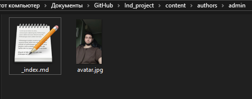

## Запись информации о себе

В той же папке открываю файл _index.md в редакторе gedit и ввожу информацию о себе (краткое описание, интересы, образование)

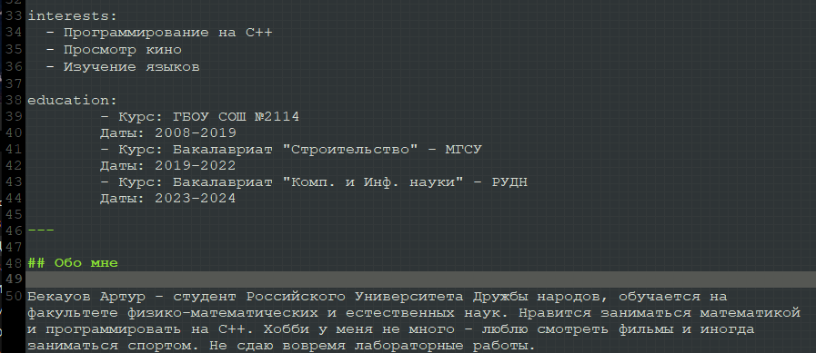

## Локальный сервер - проверка bio

с помощью hugo server запускаю локальный сервер и проверяю корректность изменений.

[figure not shown]

## Пост о прошедшей неделе

Далее перехожу в каталог Ind_project/content/posts и создаю две папки post 1 и post 2 на подобе остальных имеющихся там. Открываю папку post 1, открываю в gedit файл index.md и делаю пост о прошедшей неделе.

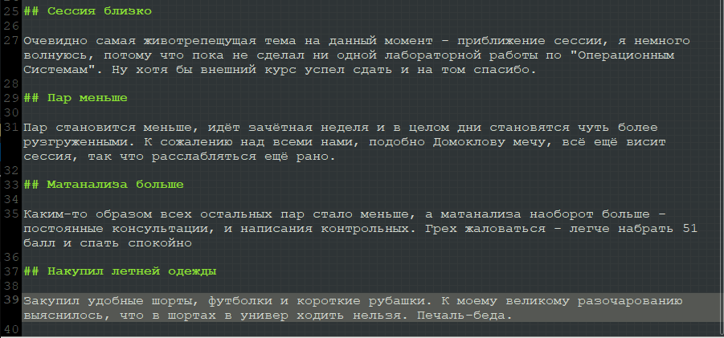

## Пост о Git

Открываю папку post 2, открываю в gedit файл index.md и делаю пост о системе контроля версий Git

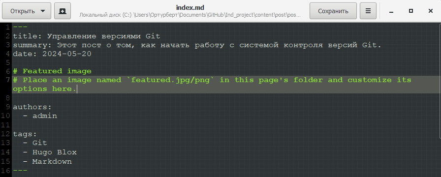

## Локальный сервер - проверка постов

Ещё раз запускаю локальный сервер и проверяю посты.

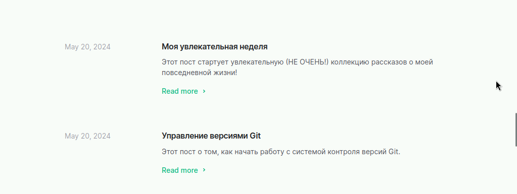

## Перенос изменений на сайт

Ввожу в репозитории Ind_project команду /~/bin/hugo. Далее перехожу в public и отправляю изменения на репозиторий atbekauov.github.io.

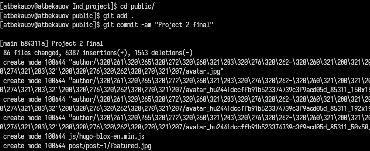

## Проверка сайта - bio

Захожу на сайт и проверяю свою карточку.

[figure not shown]

## Проверка сайта - пост недели

Также проверяю пост про неделю.

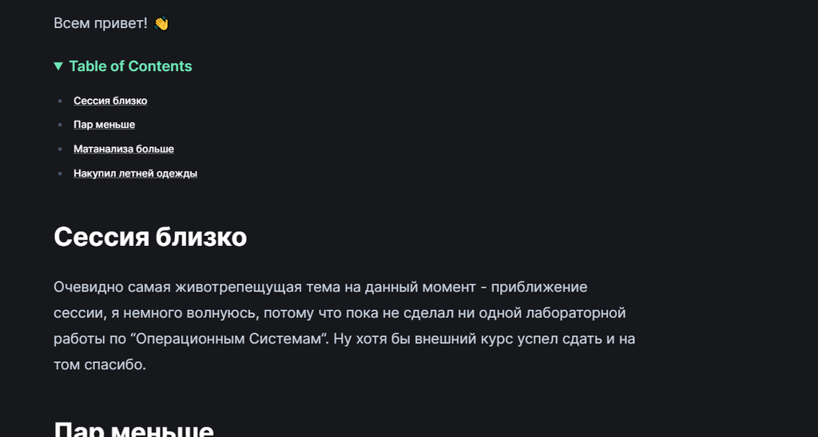

## Проверка сайта - пост о Git

Затем проверяю пост про Git.

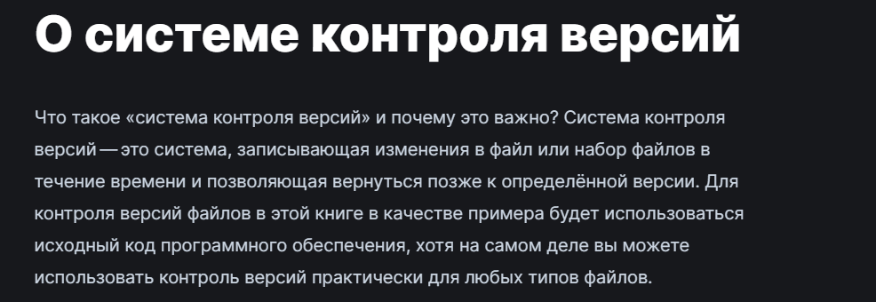

# Заключение

## Выводы

В ходе данной лаботраторной работы я добавил данные о себе на сайт и выполнил второй этап индивидуального проекта.